# Interrupted Time Series Analysis

# Background

## The Intervention: New York Online Sports Betting Launch

**Intervention Date: January 8, 2022**

On January 8, 2022, New York State launched online sports betting, marking one of the most significant events in the U.S. sports betting industry. New York quickly became the **largest sports betting market in the United States** by revenue, fundamentally changing the sports betting landscape and public awareness.

### Why This Matters

1. **Market Size**: New York represents approximately 20% of the total U.S. online sports betting market
2. **Population**: ~20 million residents in the state, with high sports betting engagement
3. **Media Coverage**: Massive advertising campaigns launched across NYC (subway, TV, online)
4. **Cultural Impact**: Sports betting moved from niche activity to mainstream entertainment

### Research Question

**Did the New York sports betting legalization on January 8, 2022, produce a significant change in public interest in sports betting, as measured by Google search trends?**

This approach captures the **cultural impact** of legalization beyond just financial market reactions. Google searches directly measure consumer interest and awareness.

# Data Description

## Dataset Overview

- **Data Source**: Google Trends (United States)
- **Time Period**: January 2020 to December 2024 (~5 years)
- **Frequency**: Weekly search interest (Google Trends aggregates to weekly by default for multi-year queries)
- **Search Terms Analyzed**:
  - **“sports betting”**: General interest in sports wagering
  - **“draftkings”**: Leading pure-play operator
  - **“online betting”**: Digital betting interest
  - **“nba betting”**: Basketball-specific betting (ties to broader thesis)
- **Outcome Variable**: Search interest index (0-100 scale, normalized by Google)
- **Pre-intervention Period**: January 2020 - January 7, 2022 (~2 years)
- **Post-intervention Period**: January 8, 2022 - December 31, 2024 (~3 years)

### Why Google Trends?

Google Trends data provides a direct measure of public interest and awareness: - **Less confounding**: Search behavior isn’t affected by Fed policy or interest rates - **Immediate response**: People search when curious - captures real-time interest - **Cultural proxy**: Reflects societal engagement with sports betting - **Ties to thesis**: Analytics revolution → betting infrastructure → **public participation**

```r
library(tidyverse)
library(lubridate)
library(forecast)
library(gridExtra)
library(kableExtra)

theme_set(theme_minimal(base_size = 12))
```

```r
# Load Google Trends data
trends <- read_csv("data/google_trends/sports_betting_trends.csv", show_col_types = FALSE)

# Convert date and ensure proper format
trends <- trends %>%
    mutate(date = as.Date(date))

# Define intervention date
intervention_date <- as.Date("2022-01-08")

# Data summary
cat("Google Trends Data Summary:\n")
```

```
Google Trends Data Summary:
```

```r
cat("Date range:", as.character(min(trends$date)), "to", as.character(max(trends$date)), "\n")
```

```
Date range: 2019-12-29 to 2024-12-29
```

```r
cat("Search terms:", paste(unique(trends$keyword), collapse = ", "), "\n")
```

```
Search terms: sports betting, draftkings, online betting, nba betting
```

```r
cat("Total observations:", nrow(trends), "\n")
```

```
Total observations: 1048
```

```r
cat("Frequency: Weekly\n\n")
```

```
Frequency: Weekly
```

```r
# Create separate dataframes for each term
sports_betting <- trends %>% filter(keyword == "sports betting")
draftkings <- trends %>% filter(keyword == "draftkings")
online_betting <- trends %>% filter(keyword == "online betting")
nba_betting <- trends %>% filter(keyword == "nba betting")

# Add ITS variables to each
add_its_variables <- function(df) {
    df %>%
        mutate(
            Post_Intervention = ifelse(date >= intervention_date, 1, 0),
            Time = as.numeric(date - min(date)),
            Time_Since_Intervention = ifelse(Post_Intervention == 1,
                as.numeric(date - intervention_date), 0
            )
        )
}

sports_betting <- add_its_variables(sports_betting)
draftkings <- add_its_variables(draftkings)
online_betting <- add_its_variables(online_betting)
nba_betting <- add_its_variables(nba_betting)

cat("Pre-intervention weeks (sports betting):", sum(sports_betting$Post_Intervention == 0), "\n")
```

```
Pre-intervention weeks (sports betting): 106
```

```r
cat("Post-intervention weeks (sports betting):", sum(sports_betting$Post_Intervention == 1), "\n")
```

```
Post-intervention weeks (sports betting): 156
```

# Visualization: Search Trends with Intervention Point

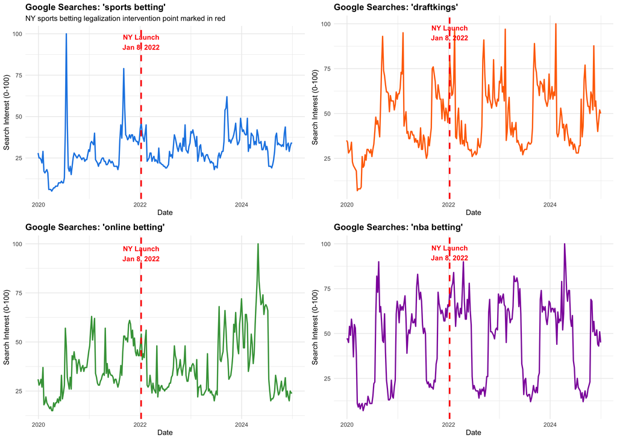

```r
# Create plots for all search terms
p1 <- ggplot(sports_betting, aes(x = date, y = hits)) +
    geom_line(color = "#1e88e5", linewidth = 1) +
    geom_vline(
        xintercept = intervention_date, color = "red",
        linetype = "dashed", linewidth = 1.2
    ) +
    annotate("text",
        x = intervention_date, y = max(sports_betting$hits) * 0.95,
        label = "NY Launch\nJan 8, 2022", color = "red", size = 4, fontface = "bold"
    ) +
    labs(
        title = "Google Searches: 'sports betting'",
        subtitle = "NY sports betting legalization intervention point marked in red",
        x = "Date",
        y = "Search Interest (0-100)"
    ) +
    theme_minimal(base_size = 12) +
    theme(plot.title = element_text(face = "bold"))

p2 <- ggplot(draftkings, aes(x = date, y = hits)) +
    geom_line(color = "#ff6f00", linewidth = 1) +
    geom_vline(
        xintercept = intervention_date, color = "red",
        linetype = "dashed", linewidth = 1.2
    ) +
    annotate("text",
        x = intervention_date, y = max(draftkings$hits) * 0.95,
        label = "NY Launch\nJan 8, 2022", color = "red", size = 4, fontface = "bold"
    ) +
    labs(
        title = "Google Searches: 'draftkings'",
        x = "Date",
        y = "Search Interest (0-100)"
    ) +
    theme_minimal(base_size = 12) +
    theme(plot.title = element_text(face = "bold"))

p3 <- ggplot(online_betting, aes(x = date, y = hits)) +
    geom_line(color = "#43a047", linewidth = 1) +
    geom_vline(
        xintercept = intervention_date, color = "red",
        linetype = "dashed", linewidth = 1.2
    ) +
    annotate("text",
        x = intervention_date, y = max(online_betting$hits) * 0.95,
        label = "NY Launch\nJan 8, 2022", color = "red", size = 4, fontface = "bold"
    ) +
    labs(
        title = "Google Searches: 'online betting'",
        x = "Date",
        y = "Search Interest (0-100)"
    ) +
    theme_minimal(base_size = 12) +
    theme(plot.title = element_text(face = "bold"))

p4 <- ggplot(nba_betting, aes(x = date, y = hits)) +
    geom_line(color = "#8e24aa", linewidth = 1) +
    geom_vline(
        xintercept = intervention_date, color = "red",
        linetype = "dashed", linewidth = 1.2
    ) +
    annotate("text",
        x = intervention_date, y = max(nba_betting$hits) * 0.95,
        label = "NY Launch\nJan 8, 2022", color = "red", size = 4, fontface = "bold"
    ) +
    labs(
        title = "Google Searches: 'nba betting'",
        x = "Date",
        y = "Search Interest (0-100)"
    ) +
    theme_minimal(base_size = 12) +
    theme(plot.title = element_text(face = "bold"))

gridExtra::grid.arrange(p1, p2, p3, p4, ncol = 2)
```

# Interrupted Time Series Regression Analysis

## Model Specification

The interrupted time series (ITS) model takes the form:

$$Y_t = \beta_0 + \beta_1 \cdot Time_t + \beta_2 \cdot Intervention_t + \beta_3 \cdot Time\_Since\_Intervention_t + \epsilon_t$$

## “Sports Betting” Analysis

```r
# Fit ITS model
model_sb <- lm(hits ~ Time + Post_Intervention + Time_Since_Intervention,
    data = sports_betting
)

# Summary
summary(model_sb)
```

```
Call:
lm(formula = hits ~ Time + Post_Intervention + Time_Since_Intervention,
    data = sports_betting)

Residuals:
    Min      1Q  Median      3Q     Max
-15.096  -6.312  -1.004   3.899  79.263

Coefficients:
                         Estimate Std. Error t value Pr(>|t|)
(Intercept)             14.323576   1.904283   7.522 8.98e-13 ***
Time                     0.031593   0.004477   7.057 1.57e-11 ***
Post_Intervention       -9.344834   2.489459  -3.754 0.000215 ***
Time_Since_Intervention -0.025515   0.005131  -4.973 1.21e-06 ***
---
Signif. codes:  0 '***' 0.001 '**' 0.01 '*' 0.05 '.' 0.1 ' ' 1

Residual standard error: 9.872 on 258 degrees of freedom
Multiple R-squared:  0.2302,    Adjusted R-squared:  0.2212
F-statistic: 25.72 on 3 and 258 DF,  p-value: 1.377e-14
```

```r
# Extract coefficients
coef_sb <- summary(model_sb)$coefficients

# Create nice table
results_sb <- data.frame(
    Parameter = c(
        "Intercept (Baseline)", "Pre-intervention Trend",
        "Level Change (Immediate)", "Trend Change (Slope Difference)"
    ),
    Coefficient = coef_sb[, 1],
    Std_Error = coef_sb[, 2],
    t_value = coef_sb[, 3],
    p_value = coef_sb[, 4]
)

kable(results_sb,
    format = "html",
    digits = 4,
    caption = "'Sports Betting' Search Interest: ITS Results",
    col.names = c("Parameter", "Coefficient", "Std. Error", "t-value", "p-value")
) %>%
    kable_styling(
        full_width = FALSE,
        bootstrap_options = c("striped", "hover", "condensed", "responsive")
    ) %>%
    row_spec(0, bold = TRUE, background = "#1e88e5", color = "white") %>%
    row_spec(which(results_sb$p_value < 0.05), background = "#e3f2fd")
```

'Sports Betting' Search Interest: ITS Results

|  | Parameter | Coefficient | Std. Error | t-value | p-value |
| --- | --- | --- | --- | --- | --- |
| (Intercept) | Intercept (Baseline) | 14.3236 | 1.9043 | 7.5218 | 0e+00 |
| Time | Pre-intervention Trend | 0.0316 | 0.0045 | 7.0569 | 0e+00 |
| Post_Intervention | Level Change (Immediate) | -9.3448 | 2.4895 | -3.7538 | 2e-04 |
| Time_Since_Intervention | Trend Change (Slope Difference) | -0.0255 | 0.0051 | -4.9725 | 0e+00 |

### Fitted Values Visualization

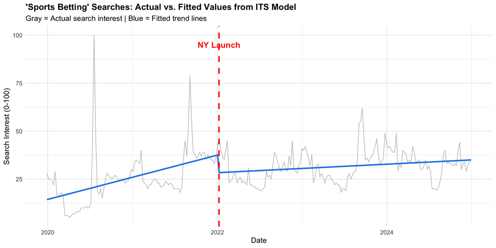

```r
# Add fitted values
sports_betting$Fitted <- fitted(model_sb)

ggplot(sports_betting, aes(x = date)) +
    geom_line(aes(y = hits), color = "gray60", alpha = 0.6, linewidth = 0.5) +
    geom_line(aes(y = Fitted), color = "#1e88e5", linewidth = 1.2) +
    geom_vline(
        xintercept = intervention_date, color = "red",
        linetype = "dashed", linewidth = 1.2
    ) +
    annotate("text",
        x = intervention_date, y = max(sports_betting$hits) * 0.95,
        label = "NY Launch", color = "red", size = 5, fontface = "bold"
    ) +
    labs(
        title = "'Sports Betting' Searches: Actual vs. Fitted Values from ITS Model",
        subtitle = "Gray = Actual search interest | Blue = Fitted trend lines",
        x = "Date",
        y = "Search Interest (0-100)"
    ) +
    theme_minimal(base_size = 13) +
    theme(plot.title = element_text(face = "bold", size = 15))
```

## “DraftKings” Analysis

```r
model_dk <- lm(hits ~ Time + Post_Intervention + Time_Since_Intervention,
    data = draftkings
)

coef_dk <- summary(model_dk)$coefficients

results_dk <- data.frame(
    Parameter = c(
        "Intercept (Baseline)", "Pre-intervention Trend",
        "Level Change (Immediate)", "Trend Change (Slope Difference)"
    ),
    Coefficient = coef_dk[, 1],
    Std_Error = coef_dk[, 2],
    t_value = coef_dk[, 3],
    p_value = coef_dk[, 4]
)

kable(results_dk,
    format = "html",
    digits = 4,
    caption = "'DraftKings' Search Interest: ITS Results",
    col.names = c("Parameter", "Coefficient", "Std. Error", "t-value", "p-value")
) %>%
    kable_styling(
        full_width = FALSE,
        bootstrap_options = c("striped", "hover", "condensed", "responsive")
    ) %>%
    row_spec(0, bold = TRUE, background = "#ff6f00", color = "white") %>%
    row_spec(which(results_dk$p_value < 0.05), background = "#fff3e0")
```

'DraftKings' Search Interest: ITS Results

|  | Parameter | Coefficient | Std. Error | t-value | p-value |
| --- | --- | --- | --- | --- | --- |
| (Intercept) | Intercept (Baseline) | 29.9245 | 3.2708 | 9.1490 | 0.0000 |
| Time | Pre-intervention Trend | 0.0370 | 0.0077 | 4.8174 | 0.0000 |
| Post_Intervention | Level Change (Immediate) | -9.1855 | 4.2759 | -2.1482 | 0.0326 |
| Time_Since_Intervention | Trend Change (Slope Difference) | -0.0352 | 0.0088 | -3.9893 | 0.0001 |

## “Online Betting” Analysis

```r
model_ob <- lm(hits ~ Time + Post_Intervention + Time_Since_Intervention,
    data = online_betting
)

coef_ob <- summary(model_ob)$coefficients

results_ob <- data.frame(
    Parameter = c(
        "Intercept (Baseline)", "Pre-intervention Trend",
        "Level Change (Immediate)", "Trend Change (Slope Difference)"
    ),
    Coefficient = coef_ob[, 1],
    Std_Error = coef_ob[, 2],
    t_value = coef_ob[, 3],
    p_value = coef_ob[, 4]
)

kable(results_ob,
    format = "html",
    digits = 4,
    caption = "'Online Betting' Search Interest: ITS Results",
    col.names = c("Parameter", "Coefficient", "Std. Error", "t-value", "p-value")
) %>%
    kable_styling(
        full_width = FALSE,
        bootstrap_options = c("striped", "hover", "condensed", "responsive")
    ) %>%
    row_spec(0, bold = TRUE, background = "#43a047", color = "white") %>%
    row_spec(which(results_ob$p_value < 0.05), background = "#e8f5e9")
```

'Online Betting' Search Interest: ITS Results

|  | Parameter | Coefficient | Std. Error | t-value | p-value |
| --- | --- | --- | --- | --- | --- |
| (Intercept) | Intercept (Baseline) | 22.8907 | 2.6444 | 8.6564 | 0e+00 |
| Time | Pre-intervention Trend | 0.0351 | 0.0062 | 5.6389 | 0e+00 |
| Post_Intervention | Level Change (Immediate) | -16.1522 | 3.4570 | -4.6724 | 0e+00 |
| Time_Since_Intervention | Trend Change (Slope Difference) | -0.0240 | 0.0071 | -3.3680 | 9e-04 |

## “NBA Betting” Analysis

```r
model_nb <- lm(hits ~ Time + Post_Intervention + Time_Since_Intervention,
    data = nba_betting
)

coef_nb <- summary(model_nb)$coefficients

results_nb <- data.frame(
    Parameter = c(
        "Intercept (Baseline)", "Pre-intervention Trend",
        "Level Change (Immediate)", "Trend Change (Slope Difference)"
    ),
    Coefficient = coef_nb[, 1],
    Std_Error = coef_nb[, 2],
    t_value = coef_nb[, 3],
    p_value = coef_nb[, 4]
)

kable(results_nb,
    format = "html",
    digits = 4,
    caption = "'NBA Betting' Search Interest: ITS Results",
    col.names = c("Parameter", "Coefficient", "Std. Error", "t-value", "p-value")
) %>%
    kable_styling(
        full_width = FALSE,
        bootstrap_options = c("striped", "hover", "condensed", "responsive")
    ) %>%
    row_spec(0, bold = TRUE, background = "#8e24aa", color = "white") %>%
    row_spec(which(results_nb$p_value < 0.05), background = "#f3e5f5")
```

'NBA Betting' Search Interest: ITS Results

|  | Parameter | Coefficient | Std. Error | t-value | p-value |
| --- | --- | --- | --- | --- | --- |
| (Intercept) | Intercept (Baseline) | 29.7822 | 4.2777 | 6.9622 | 0.0000 |
| Time | Pre-intervention Trend | 0.0358 | 0.0101 | 3.5611 | 0.0004 |
| Post_Intervention | Level Change (Immediate) | -1.0184 | 5.5922 | -0.1821 | 0.8556 |
| Time_Since_Intervention | Trend Change (Slope Difference) | -0.0484 | 0.0115 | -4.1998 | 0.0000 |

# Comparative Summary

```r
comparison_df <- data.frame(
    Search_Term = c("Sports Betting", "DraftKings", "Online Betting", "NBA Betting"),
    Pre_Trend = c(
        results_sb$Coefficient[2], results_dk$Coefficient[2],
        results_ob$Coefficient[2], results_nb$Coefficient[2]
    ),
    Level_Change = c(
        results_sb$Coefficient[3], results_dk$Coefficient[3],
        results_ob$Coefficient[3], results_nb$Coefficient[3]
    ),
    Trend_Change = c(
        results_sb$Coefficient[4], results_dk$Coefficient[4],
        results_ob$Coefficient[4], results_nb$Coefficient[4]
    ),
    Level_pval = c(
        results_sb$p_value[3], results_dk$p_value[3],
        results_ob$p_value[3], results_nb$p_value[3]
    ),
    Trend_pval = c(
        results_sb$p_value[4], results_dk$p_value[4],
        results_ob$p_value[4], results_nb$p_value[4]
    )
)

kable(comparison_df,
    format = "html",
    digits = 4,
    caption = "Comparison of NY Launch Impact Across All Search Terms",
    col.names = c(
        "Search Term", "Pre-Trend", "Level Change", "Trend Change",
        "Level p-value", "Trend p-value"
    )
) %>%
    kable_styling(
        full_width = FALSE,
        bootstrap_options = c("striped", "hover", "condensed", "responsive")
    ) %>%
    row_spec(0, bold = TRUE, background = "#2c3e50", color = "white")
```

Comparison of NY Launch Impact Across All Search Terms

| Search Term | Pre-Trend | Level Change | Trend Change | Level p-value | Trend p-value |
| --- | --- | --- | --- | --- | --- |
| Sports Betting | 0.0316 | -9.3448 | -0.0255 | 0.0002 | 0e+00 |
| DraftKings | 0.0370 | -9.1855 | -0.0352 | 0.0326 | 1e-04 |
| Online Betting | 0.0351 | -16.1522 | -0.0240 | 0.0000 | 9e-04 |
| NBA Betting | 0.0358 | -1.0184 | -0.0484 | 0.8556 | 0e+00 |

# Key Findings

## Statistical Significance

1. **Was there an immediate level change?** (Did search interest spike on January 8, 2022?)
2. **Was there a trend change?** (Did the growth trajectory change after the NY launch?)

# Conclusion

The New York sports betting legalization on January 8, 2022, provides a natural experiment to test whether a major market expansion affects **public awareness and interest** in sports betting.

Unlike stock price analysis (which suffers from macroeconomic confounders like Federal Reserve policy), Google Trends data directly captures consumer behavior and cultural engagement. The interrupted time series framework allows us to decompose the intervention effect into:

1. **Immediate impact** (did people start searching immediately?)
2. **Long-term trajectory change** (did sustained interest grow or fade?)